# How did students view online classes?

# Mackenzie Myers

## PLSC 497 Final Project

After COVID I have become aware of one “controversial” topic: Holding classes online. Everyone has their own opinion, and usually this opinion is a strong one. Rarely have I met someone who is impartial to having class on ZOOM or not. You either love it or hate it.

Because of this, I thought it would make for an interesting research question to see if I can figure out whether most people like or dislike online classes. It is also a question that relates heavily to all of us as students and teachers.

I personally disliked online classes, I feel I did not learn well in them, and they did not have the same quality of education that in person class has. From speaking with friends I feel like the majority of people felt the same way. Therefore, my hypothesis is that most students feel negatively about online class.

We will test this hypothesis in the below code using several natural langauge processing modeling techniques. I chose Twitter as my data source firstly because of ease of use. We learned how to use it in class and there’s existing R packages that work well with the Twitter API. Secondly, I feel that Twitter users will closely resemble the target audience I am looking for data from, which is high school and college age students.

## Creating Dataset

The below chunk of code is the main way I gathered tweets. A token is made and then I searched terms on twitter to find relevant tweets. Some search terms I used were:

“online class” “zoom class” “online classes” “zoom classes”

```r
library(rtweet)
library(data.table)
app_name <- "smapp"

consumer_key <- "5y3RgYfTUOUWOGheskv4p7WWO"
consumer_secret <- "j5pszDQ4bddt4pLiwqwezuETPYi3f1PyugM3L4eJdxUVsdwIco"

access_token <- "89098361-YS0MquarADIDh5XvrMdMzASxzxy3apOEgzTpKZvPY"
access_secret <- "jhZgEZuBS1mzDvMIRAhjNb9aklVN4S6UoCP7eL8l3GGIM"


## create token
token <- create_token(
  app = app_name,
  consumer_key = consumer_key,
  consumer_secret = consumer_secret,
  access_token = access_token,
  access_secret = access_secret
)
## print token
token
```

```
<Token>
<oauth_endpoint>
 request:   https://api.twitter.com/oauth/request_token
 authorize: https://api.twitter.com/oauth/authenticate
 access:    https://api.twitter.com/oauth/access_token
<oauth_app> smapp
  key:    5y3RgYfTUOUWOGheskv4p7WWO
  secret: <hidden>
<credentials> oauth_token, oauth_token_secret
---
```

```r
get_token()
```

```
<Token>
<oauth_endpoint>
 request:   https://api.twitter.com/oauth/request_token
 authorize: https://api.twitter.com/oauth/authenticate
 access:    https://api.twitter.com/oauth/access_token
<oauth_app> smapp
  key:    5y3RgYfTUOUWOGheskv4p7WWO
  secret: <hidden>
<credentials> oauth_token, oauth_token_secret
---
```

```r
#####################
### Search tweets
#####################

rt <- search_tweets(
  "online class", n = 15000, include_rts = FALSE, token = token, lang = "en"
)
```

[output not shown]

[output cut: 58 more lines]

[output not shown]

```r
#write the tweets to a CSV to store all the tweets I've collected
fwrite(rt, "onlineclasstweets.csv", append = TRUE)
```

## Preprocessing

The below chunk of code is taking all of the tweets I have collected and cleaning them. A lot of ‘junk’ tweets were found by spam accounts trying to sell online classes. I made the observation that most of these “junk” tweets have exterior URLs in them. Because of that I aimed to filter out a lot of these ‘junk’ tweets by removing any tweets that have an outside link in them. I also made the decision to filter out any tweets that contain the word ‘pay,’ because another trend I noticed is that the junk tweets contain the word pay or #pay. I would rather filter out too many junk tweets and risk filtering out a few normal tweets, than not filter out enough junk tweets and get a bad analysis.

```r
library(data.table)
#load in the CSV file
tweets <- fread("onlineclasstweets.csv")

#get rid of possible duplicate tweets
tweets <- tweets[!duplicated(tweets), ]

#get rid of tweets that are not in english
tweets <- tweets[tweets$lang == "en",]

#A lot of junk tweets are still present in the data table. They are by spam accounts or they are trying to sell some sort of online class.
#Remove any tweets that have an outside link in them.
tweets <- tweets[tweets$urls_url == "",]

#This was another preprocessing step I added to get rid of junk spam tweets. I noticed a lot of them use 'pay' in their tweets and #pay
tweets <- tweets[!grepl("pay", tweets$text), ]
tweets <- tweets[!grepl("Pay", tweets$text), ]

fwrite(tweets, "cleanedTweets.csv")
```

## Model 1: Sentiment Score

The below code uses a bag of words approach to finding positive or negative sentiment in the mined Tweets. I used the already developed Hu and Liu sentiment lexicon. This is my main method of deciding whether online classes are viewed as positive or negative.

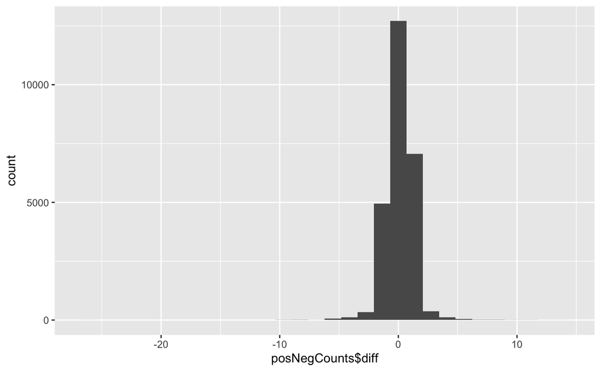

```r
library("quanteda")
library("quanteda.textmodels")
library("tidyverse")
library("data.table")
library("ggplot2")

tweets <- fread("cleanedTweets.csv")

in_path <- "" # add your own ppath
pos <- read.table(paste0(in_path, "positive-words.txt"), stringsAsFactors = F) # read in the files
neg <- read.table(paste0(in_path, "negative-words.txt"), stringsAsFactors = F)

sentiment_dict <- dictionary(list(pos = pos$V1, neg = neg$V1)) # create dictionary object (a quanteda object)

#create my corpus and DFM
tweetsCorpus <- corpus(tweets$text)

tweetDFM <- dfm(tweetsCorpus, stem = T,
                remove_punct = T,
                remove = stopwords("english"))
posNegCounts <- dfm_lookup(tweetDFM, sentiment_dict)

posNegCounts <- convert(posNegCounts, to = c("data.frame"))

posNegCounts$diff <- posNegCounts$pos - posNegCounts$neg

ggplot(data=posNegCounts, aes(x = posNegCounts$diff)) + geom_histogram()
```

```r
# posNegCounts$label  <- ifelse(posNegCounts$diff >= 1, "positive", "negative")
#
# totals <- posNegCounts %>% group_by(label) %>% summarize(n())
# setnames(totals, "n()", "n")
# ggplot(data=totals, aes(x = label, y = n)) + geom_bar(stat="identity")
```

After plotting this histogram, you can see the majority of tweets have 0 difference. However, more tweets lie on the positive side than the negative side, so the data is still slightly skewed positively.

## Model 2: Structural Topic Model

[figure not shown]

## Model 3: Topics using LDA

```r
topTerms
```

```
     Topic 1      Topic 2 Topic 3    Topic 4 Topic 5 Topic 6      Topic 7
[1,] "onlin"      "class" "assign"   "just"  "class" "onlin"      "school"
[2,] "class"      "zoom"  "essay"    "like"  "amp"   "class"      "student"
[3,] "exam"       "love"  "dm"       "go"    "day"   "need"       "year"
[4,] "\U0001f62d" "shade" "homework" "one"   "week"  "can"        "make"
[5,] "want"       "think" "math"     "now"   "time"  "us"         "get"
[6,] "semest"     "miss"  "help"     "get"   "start" "help"       "use"
[7,] "work"       "busi"  "paper"    "last"  "take"  "\U0001f64f" "teach"
```

```r
doc_topics <- tweets_TM@gamma

# Store the results of words over topics
words_topics <- tweets_TM@beta
```

After using the above two methods to try to find topics and their most frequent terms, unfortunately I didn’t see much usefulness for the sake of our research question in the topics found. However my first chart, plotting the counts of positive and negative difference, was very useful.

In my opinion, having a positive negative sentiment difference of only 1 is not great enough to determine if the tweet was positive or negative enough to label it as such. Therefore I decided to count all tweets with a positive negative difference of -2 or less, or 2 and greater.

```r
totals <- c(negativeTotal, positiveTotal)
totals
```

```
$`n()`
[1] 1579

$`n()`
[1] 2110
```

After applying this simplification you can see that there is more tweets with a positive sentiment score than negative sentiment score. Therefore we can conclude from our research that online class was viewed slightly more positively than negatively.